# esATAC Report

Zheng Wei and Wei Zhang

2017-11-20

```r
load("Report2.Rdata")
```

# 1 Summary Table

Sequence files below are set as inputs of the pipeline.

Case files:

| Mate1.files | Mate2.files |
| --- | --- |
| /home/data/ptestdata/SRR4435490_1.fastq | /home/data/ptestdata/SRR4435490_2.fastq |

Control files:

| Mate1.files | Mate2.files |
| --- | --- |
| /home/data/ptestdata/SRR4435505_1.fastq | /home/data/ptestdata/SRR4435505_2.fastq |

Summerized infomation on sequence files has been shown showed below. You can see details in later sections

| Item | Case | Control | Reference |
| --- | --- | --- | --- |
| Sequence Files Type | paired end (PE) | paired end (PE) | SE / PE |
| Original total reads | 30.3M | 28.8M |  |
| – Reads after adapter removing (ratio) | 30.3M (100.00%) | 28.8M (100.00%) | >99% |
| – – Total mapped reads (ratio of original reads) | 29.6M (97.65%) | 28.0M (97.46%) | >95% |
| – – – Unique locations mapped uniquely by reads | 15.6M | 13.0M |  |
| – – – Uniquely mappable reads | 20.8M | 18.1M |  |
| – – – Non-Redundant Fraction (NRF) | 0.75 | 0.72 | >0.7 |
| – – – Locations with only 1 reads mapping uniquely | 13.6M | 11.6M |  |
| – – – Locations with only 2 reads mapping uniquely | 1.5M | 1.0M |  |
| – – – PCR Bottlenecking Coefficients 1 (PBC1) | 0.87 | 0.89 | >0.7 |
| – – – PCR Bottlenecking Coefficients 2 (PBC2) | 8.85 | 11.67 | >3 |
| – – – Non-mitochondrial reads (ratio) | 21.0M (70.99%) | 18.2M (64.94%) | >70% |
| – – – – Unique mapped reads (ratio) | 16.5M (55.64%) | 13.2M (46.95%) |  |
| – – – – – Duplicate removed reads (final for use) | 14.6M (49.39%) | 12.1M (43.07%) | >25M |
| – – – – – – Nucleosome free reads (<100bp) | 5.7M (38.92%) | 4.3M (36.02%) |  |
| – – – – – – – Total peaks | 112926 | 112622 |  |
| – – – – – – – Peaks overlaped with union DHS ratio | 73.2% | 76.5% |  |
| – – – – – – – Peaks overlaped with blacklist ratio | 0.1% | 0.1% |  |
| – – – – – – Fraction of reads in peaks (FRiP) | 56.7% | 67.6% |  |

A nucleosome free region (NFR) must be present. A mononucleosome peak must be present in the fragment length distribution. These are reads that span a single nucleosome, so they are longer than 147 bp but shorter than 147*2 bp. Good ATAC-seq datasets have reads that span nucleosomes (which allows for calling nucleosome positions in addition to open regions of chromatin).

- Case

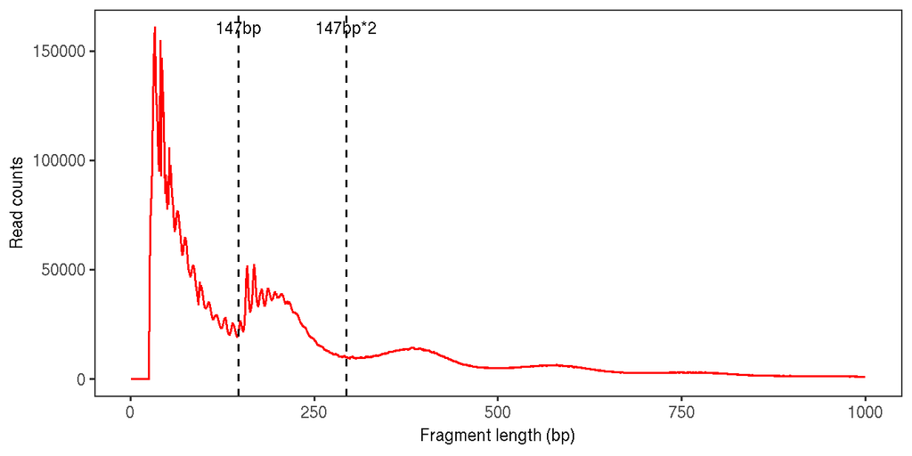

- Control

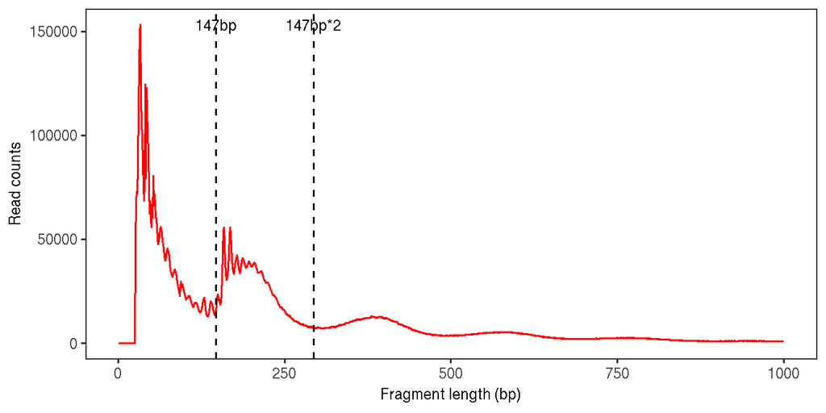

# 2 Sequence Statistics

## 2.1 FastQC

Quality control for the sequence data

Click to Visit Report for case

Click to Visit Report for control

## 2.2 Remove adapter

The adapter sequence are shown below. For paired end reads, if adapters were not setted, the adapters below are identified by AdapterRemoval.

- Adapter for case

| Item | Value |
| --- | --- |
| adapter1 | TTGTCATTTTTAAATTATATAAAATTAAAATTAAAATAAT |
| adapter2 | CTGTCTCTTTTAAATTATATAAAATTAAAATTAAAATAAT |

- Adapter for control

| Item | Value |
| --- | --- |
| adapter1 | TTGTCATTTTAAAATTATATAAAATTAAATTTATAATAAT |
| adapter2 | TTGTCTTTTTTAAATTATATAAATTTAAATTTATAATAAT |

The statistic of adapter removing are show below.

| Items | Case | Control |
| --- | --- | --- |
| Total number of read pairs | 30308983 | 28750759 |
| Number of unaligned read pairs | 13491924 | 12113590 |
| Number of well aligned read pairs | 16817059 | 16637169 |
| Number of discarded mate 1 reads | 0 | 2 |
| Number of singleton mate 1 reads | 0 | 0 |
| Number of discarded mate 2 reads | 0 | 2 |
| Number of singleton mate 2 reads | 0 | 0 |
| Number of reads with adapters[1] | 225206 | 257949 |
| Number of retained reads | 60617966 | 57501514 |
| Number of retained nucleotides | 3002145413 | 2836808896 |
| Average length of retained reads | 49.5257 | 49.3345 |

For detail, you can visit [Website of AdapterRemoval on Github](https://github.com/MikkelSchubert/adapterremoval).

# 3 Reads Alignment Statistics

## 3.1 Bowtie2 alignment log

- For case

```
## [1] "30308983 reads; of these:"
## [2] "  30308983 (100.00%) were paired; of these:"
## [3] "    713067 (2.35%) aligned concordantly 0 times"
## [4] "    20792835 (68.60%) aligned concordantly exactly 1 time"
## [5] "    8803081 (29.04%) aligned concordantly >1 times"
## [6] "97.65% overall alignment rate"
```

- For control

```
## [1] "28750757 reads; of these:"
## [2] "  28750757 (100.00%) were paired; of these:"
## [3] "    728979 (2.54%) aligned concordantly 0 times"
## [4] "    18060564 (62.82%) aligned concordantly exactly 1 time"
## [5] "    9961214 (34.65%) aligned concordantly >1 times"
## [6] "97.46% overall alignment rate"
```

## 3.2 Library complexity

| Items | Case | Control | Reference |
| --- | --- | --- | --- |
| Total mapped reads (ratio of original reads) | 29.6M (29595916) | 28.0M (28021778) |  |
| Unique locations mapped uniquely by reads | 15.6M (15566819) | 13.0M (12989757) |  |
| Uniquely mappable reads | 20.8M (20786314) | 18.1M (18053298) |  |
| Non-Redundant Fraction (NRF) | 0.75 | 0.72 | >0.7 |
| Locations with only 1 reads mapping uniquely | 13.6M (13576805) | 11.6M (11597756) |  |
| Locations with only 2 reads mapping uniquely | 1.5M (1533927) | 1.0M (993861) |  |
| PCR Bottlenecking Coefficients 1 (PBC1) | 0.87 | 0.89 | >0.7 |
| PCR Bottlenecking Coefficients 2 (PBC2) | 8.85 | 11.67 | >3 |
| The annotation you can see in section 1. |  |  |  |

## 3.3 Filtering statistics

| Item | Case | Control | Reference |
| --- | --- | --- | --- |
| Original total reads | 30.3M (30308983) | 28.8M (28750759) |  |
| Reads after adapter removing (ratio) | 30.3M (100.00%, 30308983 / 30308983) | 28.8M (100.00%, 28750757 / 28750759) | >99% |
| Total mapped reads (ratio of original reads) | 29.6M (97.65%, 29595916 / 30308983) | 28.0M (97.46%, 28021778 / 28750759) | >95% |
| – Non-mitochondrial reads (ratio) | 21.0M (70.99%, 21009162 / 29595916) | 18.2M (64.94%, 18198637 / 28021778) | >70% |
| – – Unique mapped reads (ratio) | 16.5M (55.64%, 16468586 / 29595916) | 13.2M (46.95%, 13155966 / 28021778) | >60% |
| – – – Duplicate removed reads (ratio final for use) | 14.6M (49.39%, 14618814 / 29595916) | 12.1M (43.07%, 12069484 / 28021778) | >25M,>60% |

## 3.4 Fragment size distribution

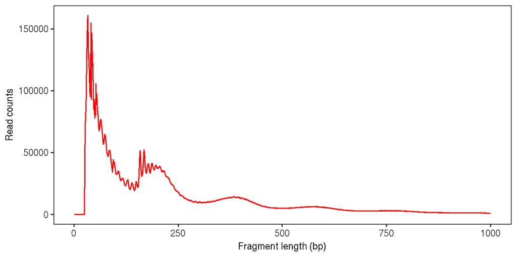

```r
library(ggplot2)
library(stats)
load("Report2.Rdata")

getFsdG1G2 <- function(readsCounts){



    strength<-Mod(fft(readsCounts$counts))/length(readsCounts$counts)
    periodx<-length(readsCounts$counts)/(1:(length(readsCounts$counts)-1))
    strength<-strength[2:length(strength)]

    rs1<-as.data.frame(cbind(periodx[periodx<20&periodx>2],strength[periodx<20&periodx>2],0))
    rs2<-as.data.frame(cbind(periodx[periodx<400&periodx>2],strength[periodx<400&periodx>2],1))
    rs<-rbind(rs1,rs2)
    colnames(rs)<-c("period","strength","check")

    g1<-ggplot(rs[rs["check"]==0,]) + geom_vline(xintercept = 10.4, linetype=2)+ geom_line(aes(x=period,y=strength),color="Red")+ theme_bw() + theme(panel.grid =element_blank()) + annotate("text", x = 10.4, y = max(rs[rs["check"]==0,2]), label = "10.4bp") +xlab("period") + ylab("strength")

    g2<-ggplot(rs[rs["check"]==1,]) + geom_vline(xintercept = 186, linetype=2)+ geom_line(aes(x=period,y=strength),color="Red")+ theme_bw() + theme(panel.grid =element_blank()) + annotate("text", x = 186, y = max(rs[rs["check"]==1,2]), label = "186bp") +xlab("period") + ylab("strength")
    return(list(g1,g2))
}
readsCounts1<-getReportVal(caselist$atacProcs$fragLenDistr,"readsCounts")
readsCounts2<-getReportVal(ctrllist$atacProcs$fragLenDistr,"readsCounts")
ggplot(readsCounts1[1:1000,], aes(length,counts))+geom_path(color="Red")+xlab("Fragment length (bp)")+ylab("Read counts") + theme_bw() + theme(panel.grid =element_blank())
```

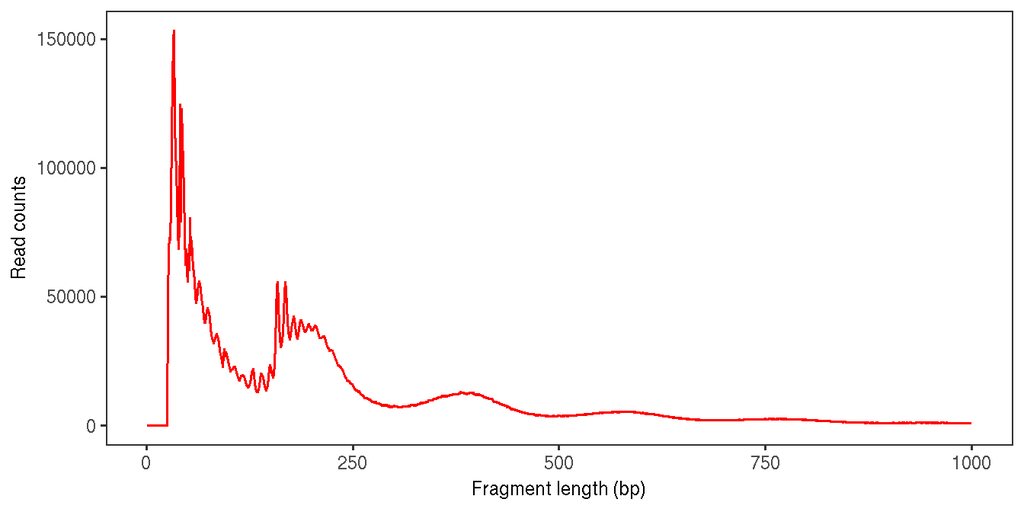

```r
ggplot(readsCounts2[1:1000,], aes(length,counts))+geom_path(color="Red")+xlab("Fragment length (bp)")+ylab("Read counts") + theme_bw() + theme(panel.grid =element_blank())
```

```r
g112<-getFsdG1G2(readsCounts1)
g212<-getFsdG1G2(readsCounts2)

library(gridExtra)
```

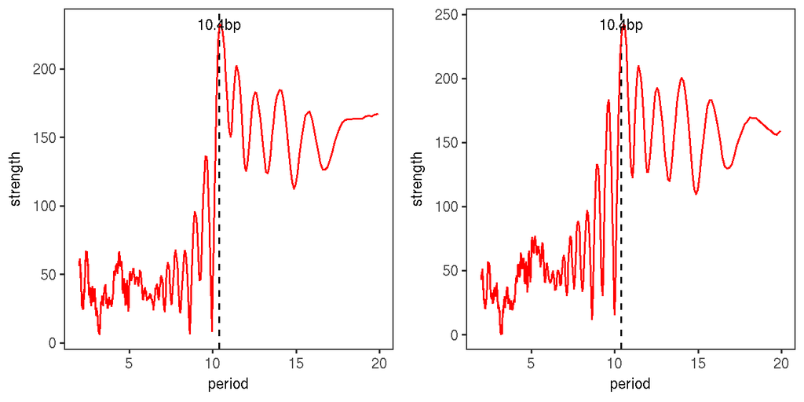

```r
grid.arrange(g112[[1]], g212[[1]],ncol=2)
```

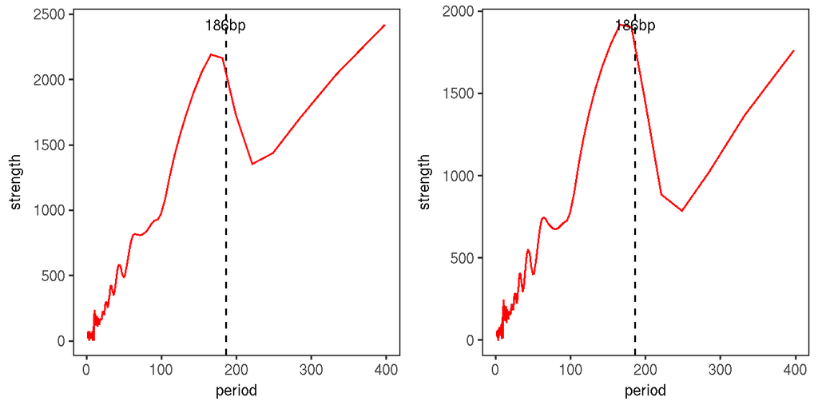

```r
grid.arrange(g112[[2]], g212[[2]],ncol=2)
```

## 3.5 TSS enrichment

The nucleosome free reads (<100bp) and monnucleosome span reads (180~247bp) enrichment around transcription starting site (TSS) are shown below.

[figure not shown]

```r
library(ggplot2)
library(gridExtra)
load("Report2.Rdata")
df<-getReportVal(caselist$atacProcs$tssqc100,"tss")
g11<-ggplot(df,aes(pos,counts))+geom_line()+ geom_vline(xintercept = 0, linetype=2)+xlab("upstream<-TSS->downstream")+ylab("reads count")+theme_bw() + theme(panel.grid =element_blank())
df<-getReportVal(caselist$atacProcs$tssqc180_247,"tss")
g12<-ggplot(df,aes(pos,counts))+geom_line()+ geom_vline(xintercept = 0, linetype=2)+xlab("upstream<-TSS->downstream")+ylab("reads count")+theme_bw() + theme(panel.grid =element_blank())

df<-getReportVal(caselist$atacProcs$tssqc100,"tss")
g21<-ggplot(df,aes(pos,counts))+geom_line()+ geom_vline(xintercept = 0, linetype=2)+xlab("upstream<-TSS->downstream")+ylab("reads count")+theme_bw() + theme(panel.grid =element_blank())
df<-getReportVal(caselist$atacProcs$tssqc180_247,"tss")
g22<-ggplot(df,aes(pos,counts))+geom_line()+ geom_vline(xintercept = 0, linetype=2)+xlab("upstream<-TSS->downstream")+ylab("reads count")+theme_bw() + theme(panel.grid =element_blank())
grid.arrange(g11, g21, ncol=2)
```

[figure not shown]

```r
grid.arrange(g12, g22, ncol=2)
```

# 4 Peak Statistics

## 4.1 Blacklist ratio

| Items | Case | Control |
| --- | --- | --- |
| Total peaks | 112926 | 112622 |
| Blacklist regions | 73 | 63 |
| Ratio | 0.00 | 0.00 |

## 4.2 DHS ratio

| Items | Case | Control |
| --- | --- | --- |
| Total peaks | 112926 | 112622 |
| DHS regions | 82716 | 86110 |
| Ratio | 0.73 | 0.76 |

## 4.3 Fraction of reads in peaks (FRiP)

| Items | Case | Control |
| --- | --- | --- |
| The number of reads in peak | 3224868 | 2937937 |
| The number of total reads | 5689342 | 4347435 |
| The number of total peaks | 112926 | 112622 |
| FRiP | 0.57 | 0.68 |

## 4.4 Peak annotation

- For case

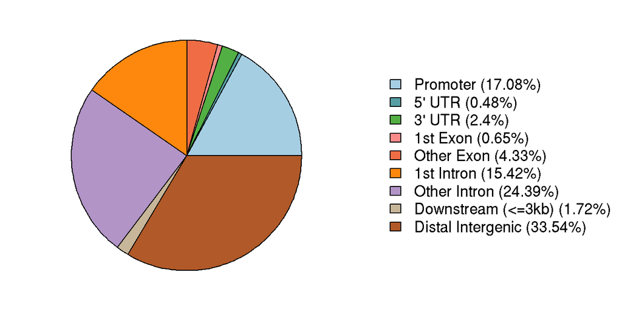

- For control

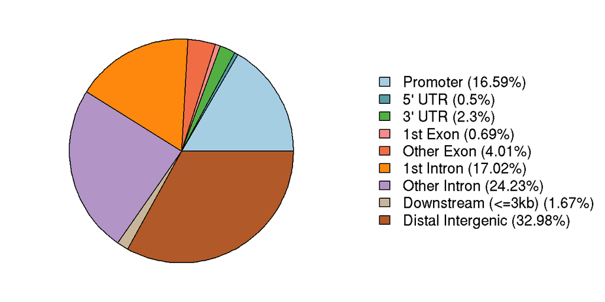

# 5 Case Control Peak Compare

The following is the peak comparation result for case and control.

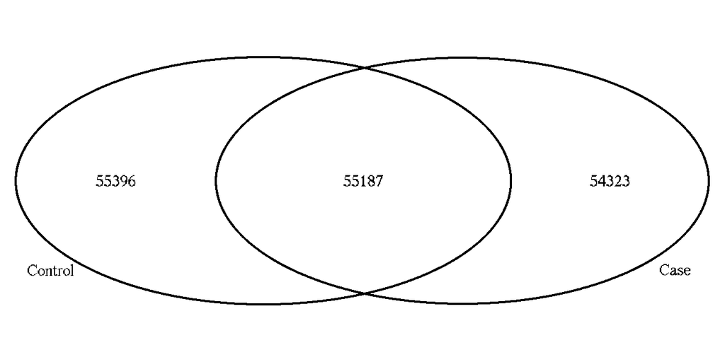

The total peaks in case are 112926, specific peaks in case are 54323.

The total peaks in control are 112622, specific peaks in control are 55396.

The overlap peaks are merged to 55187 peaks.

# 6 GO Analysis

Gene ontology analysis for all genes around specific peak regions of case and control.

## 6.1 Significant GO terms of genes associated with case specific peaks

| ID | Description | GeneRatio | pvalue | qvalue |
| --- | --- | --- | --- | --- |
| GO:0051345 | positive regulation of hydrolase activity | 400/13229 | 4.64e-38 | 9.15e-35 |
| GO:0044057 | regulation of system process | 408/13229 | 6.14e-35 | 6.06e-32 |
| GO:0061564 | axon development | 378/13229 | 1.34e-32 | 8.81e-30 |
| GO:0045666 | positive regulation of neuron differentiation | 344/13229 | 5.17e-32 | 2.55e-29 |
| GO:0023061 | signal release | 368/13229 | 1.09e-31 | 4.28e-29 |
| GO:0043410 | positive regulation of MAPK cascade | 379/13229 | 2.12e-29 | 6.98e-27 |
| GO:0007409 | axonogenesis | 351/13229 | 3.16e-29 | 8.9e-27 |
| GO:0030900 | forebrain development | 306/13229 | 3.81e-29 | 9.38e-27 |
| GO:0031346 | positive regulation of cell projection organization | 341/13229 | 4.37e-29 | 9.57e-27 |
| GO:0001525 | angiogenesis | 359/13229 | 1.1e-28 | 2.17e-26 |
| GO:0048568 | embryonic organ development | 384/13229 | 1.9e-28 | 3.41e-26 |
| GO:0042326 | negative regulation of phosphorylation | 363/13229 | 3e-28 | 4.9e-26 |
| GO:0032870 | cellular response to hormone stimulus | 376/13229 | 3.23e-28 | 4.9e-26 |
| GO:0007264 | small GTPase mediated signal transduction | 338/13229 | 7.92e-28 | 1.12e-25 |
| GO:0001501 | skeletal system development | 386/13229 | 9.58e-28 | 1.26e-25 |

Click to Visit Case Differential Go Analysis file

## 6.2 Significant GO terms of genes associated with control specific peaks

| ID | Description | GeneRatio | pvalue | qvalue |
| --- | --- | --- | --- | --- |
| GO:0044089 | positive regulation of cellular component biogenesis | 377/12163 | 3.19e-32 | 7.93e-29 |
| GO:0031346 | positive regulation of cell projection organization | 326/12163 | 1.01e-29 | 8.7e-27 |
| GO:0045666 | positive regulation of neuron differentiation | 324/12163 | 1.05e-29 | 8.7e-27 |
| GO:0007264 | small GTPase mediated signal transduction | 325/12163 | 1.54e-29 | 9.55e-27 |
| GO:0022604 | regulation of cell morphogenesis | 355/12163 | 2.86e-29 | 1.42e-26 |
| GO:0061564 | axon development | 351/12163 | 6.2e-28 | 2.56e-25 |
| GO:1905114 | cell surface receptor signaling pathway involved in cell-cell signaling | 362/12163 | 1.11e-27 | 3.93e-25 |
| GO:0010976 | positive regulation of neuron projection development | 257/12163 | 1.47e-26 | 4.57e-24 |
| GO:0030900 | forebrain development | 287/12163 | 2.33e-26 | 6.43e-24 |
| GO:0035239 | tube morphogenesis | 311/12163 | 4.88e-25 | 1.21e-22 |
| GO:0033674 | positive regulation of kinase activity | 341/12163 | 9.81e-25 | 2.21e-22 |
| GO:0007409 | axonogenesis | 325/12163 | 1.09e-24 | 2.24e-22 |
| GO:0016358 | dendrite development | 219/12163 | 1.17e-24 | 2.24e-22 |
| GO:0032870 | cellular response to hormone stimulus | 349/12163 | 2.38e-24 | 4.22e-22 |
| GO:0048568 | embryonic organ development | 355/12163 | 6.08e-24 | 1.01e-21 |

Click to Visit Ctrl Differential Go Analysis file

# 7 Motif Enrichment Analysis

This function takes case and control specific peaks as foreground respectively, overlap peaks between case and control as background.

## 7.1 Significant motifs of case specific peaks

| motif | motif length | p_value |
| --- | --- | --- |
| CTCF | 19 | 3.85e-59 |
| BATFJUN | 11 | 1.39e-40 |
| USF1 | 7 | 8.03e-18 |

## 7.2 Significant motifs of control specific peaks

| motif | motif length | p_value |
| --- | --- | --- |
| USF1 | 7 | 1.47e-55 |
| CTCF | 19 | 5.27e-41 |
| BATFJUN | 11 | 1.89e-09 |

# 8 Genomic Footprint

The following is the footprint for motif occurance of case&control peaks.

[figure not shown]

The following is the footprint for motif occurance of case&control specific peaks.

[figure not shown]

All motif footprint figures are saved as pdf files.

Click to Visit Case Footprint file

Click to Visit Ctrl Footprint file

Click to Visit Case Specific Footprint file

Click to Visit Ctrl Specific Footprint file

# 9 Annotation of Items in Table

For single end sequencing data, esATAC will counts reads number.

For paired end sequencing data, esATAC will counts read pairs or fragment number.

- **Sequence files type** is the type of sequencing data: single end data and paired end data. If paired end reads are stored in one file interleavedly rather than two files, “it is call”interleaved.
- **Original total reads** is the sample’s raw total reads (pairs) number.
- **Reads after adapter removing (ratio)** is the reads (pairs) number after adapter removing and the percentage of retained reads in original total reads. The larger value shows the better quality.
- **Total mapped reads (ratio)**  
  is the reads (pairs) number mapped to reference genome and the percentage of mapped reads in original total reads (alignment rate). ENCODE recommend that the alignment rate, or percentage of mapped reads, should be greater than 95%, though values >80% may be acceptable.
- **Unique locations mapped uniquely**  
  is the number of distinct uniquely mapping reads (i.e. after removing duplicates).
- **Non-Redundant Fraction (NRF)** is the value of: Unique locations mapped uniquely (the number of positions in the genome that uniquely mappable reads map to) / the total number of uniquely mappable reads.

[output not shown]

[output not shown]

- **PCR Bottlenecking Coefficients 2 (PBC2)** is the value of: Locations with only 1 reads mapping uniquely / Locations with only 2 reads mapping uniquely. ENCODE recommend that PBC2>3 for ATAC-seq data.

| $PBC2$ value range | Bottlenecking level |
| --- | --- |
| $PBC2<1$ | Severe |
| $1\le PBC2 \le 3$ | Moderate |
| $PBC2>3$ | None |